# R_projet

Inessa Kim, Mai-Anh Pham, Nao Ueda

Dernière modif : 04/01/2023

# 1 Introduction

La santé mentale est un sujet crucial du XXIème siècle qui est devenu un enjeu majeur lors de la pandémie du COVID-19. Des nombreuses études montrent que la pandémie du COVID-19 a entrainé une hausse mondiale des problèmes de santé mentales, y compris la dépression et l’anxiété généralisée.

En effet, la propagation du virus s’est accompagnée d’une montée de l’inquiétude face à l’infection et de la mise en place de mesures restrictives ainsi que du confinement. Par ailleurs, l’isolement, la baisse d’activité physique, l’augmentation du stress et l’organisation du travail à domicile couplée à la gestion de la vie familiale sont également des facteurs qui peuvent avoir un impact sur la santé mentale.

Ainsi, pour cette étude nous nous sommes intéressées à la santé mentale et le bien-être des Français et, notamment, aux inégalités femmes-hommes dans les deux vagues de l’enquête ELIPSS « Faire face au Covid-19 ». Le fait d’observer les deux vagues de l’enquête nous permet de comparer les résultats entre le début du premier confinement et quelques mois après sa fin.

*Présentation des données*

La base de données utilisée pour notre étude provient de l’enquête Coping with COVID-19 dont l’objectif est de mesurer l’expérience social du confinement en France. Cette enquête s’est appuyée sur un dispositif empirique préexistant - ELIPSS, un panel représentatif d’environ un millier de répondants suivis longitudinalement - et l’a transformé en un baromètre permettant de suivre l’expérience du confinement en France à des intervalles réguliers (5 vagues d’enquêtes de début avril à fin mai 2020).

*Plan*

Dans un premier temps, nous allons présenter le profil général de la population observée ainsi que les variables déterminantes du bien-être et de la santé mentale. Ensuite, nous allons nous concentrer sur les facteurs qui peuvent avoir un impact sur la santé mentale des personnes enquêtées. Enfin, nous allons présenter les résultats principaux de notre étude dans la partie finale de notre dossier.

# 2 Partie principale

*Chargement des données et des libraries*

```r
library(tidyverse)
library(questionr)
library(readr)
library(knitr)
library(kableExtra)
library(ggplot2)
library(gt)
library(tibble)
library(sf)

# Vague 1 et vague 6
coco1 <- read.csv("fr.cdsp.ddi.elipss.202004coco1.csv")
coco6 <- read.csv("fr.cdsp.ddi.elipss.202010.csv")
```

## 2.1 L’obsérvation des caractéristiques socio-démographiques de la population etudiée

L’objectif est de présenter les caractéristiques principales des répondants à l’enquête.

### 2.1.1 Le sexe et l’âge

*Sexe*

```r
fct_freq_sexe <- function(x){
  recod <- fct_collapse(factor(x),
  "Homme"="1",
  "Femme"="2")
  return(recod)
}

# Recodage
coco1$sexe <- fct_freq_sexe(coco1$eayy_A1)
coco6$sexe <- fct_freq_sexe(coco6$eayy_A1)


#poids de pourcentagesde sexe par vague1
round(wtd.table(coco1$sexe, weights = coco1$coco1_POIDS,
          useNA = "ifany") %>%
  prop.table()*100,1)#<<
```

```
## Homme Femme
##  49.2  50.8
```

```r
#poids de pourcentagesde sexe par vague6
round(wtd.table(coco6$sexe, weights = coco6$POIDS_coco6,
          useNA = "ifany") %>%
  prop.table()*100,1)#<<
```

```
## Homme Femme
##    49    51
```

*Age*

```r
fct_freq_age <- function(x){
  recod <- fct_collapse(factor(x),
                        "Moins de 29 ans"=c("4","5"),
                        "De 30 à 39 ans"=c("6","7"),
                        "De 40 à 49 ans"=c("8","9"),
                        "De 50 à 59 ans"=c("10","11"),
                        "Plus de 60 ans"=c("12","13","14"))
  return(recod)
}

# Recodage
coco1$age <- fct_freq_age(coco1$eayy_A2A_rec)
coco6$age <- fct_freq_age(coco6$eayy_A2A_rec)


# Tableau vague 1(âge et sexe) :
pop_vague1<- wtd.table(coco1$age,coco1$sexe,
          weights = coco1$coco1_POIDS, useNA = "ifany") %>%
  prop(digits=1)

# Tableau vague 6(âge et sexe) :
pop_vague6<-wtd.table(coco6$age,coco6$sexe,
          weights = coco6$POIDS_coco6, useNA = "ifany") %>%
  prop(digits=1)

#fusionner les deux vagues
pop_vague <- cbind(pop_vague1, pop_vague6)
#presenter le tableau

pop_vague_df <- as.data.frame(pop_vague)
colnames(pop_vague_df) <- c("Homme", "Femme", "Total", "homme", "femme", "total")


pop_vague_df <- rownames_to_column(pop_vague_df, "Classes d'âge")


pop_vague_df %>%
  gt() %>%
  tab_spanner(label = "Vague 1", columns = c(2, 3, 4)) %>%
  tab_spanner(label = "Vague 6", columns = c(5, 6, 7)) %>%
  tab_style(style = list(cell_text(weight = "bold")),
            locations = cells_body(columns = c(4,7)))
```

| Classes d'âge | Vague 1 Homme | Vague 1 Femme | Vague 1 Total | Vague 6 homme | Vague 6 femme | Vague 6 total |
| --- | --- | --- | --- | --- | --- | --- |
| Moins de 29 ans | 3.447328 | 5.302326 | 8.749654 | 4.158056 | 4.735784 | 8.89384 |
| De 30 à 39 ans | 7.385568 | 12.401910 | 19.787478 | 7.626017 | 11.670902 | 19.29692 |
| De 40 à 49 ans | 8.767025 | 9.644617 | 18.411642 | 8.914665 | 9.590478 | 18.50514 |
| De 50 à 59 ans | 9.451895 | 8.947422 | 18.399317 | 8.281460 | 10.017931 | 18.29939 |
| Plus de 60 ans | 20.139464 | 14.512445 | 34.651909 | 20.039802 | 14.964905 | 35.00471 |
| Total | 49.191281 | 50.808719 | 100.000000 | 49.020000 | 50.980000 | 100.00000 |

Les répondants à notre enquête proviennent des vagues 1 et 6. Le rapport entre les sexes est de 49:51 dans les deux cas, avec une proportion légèrement plus élevée des femmes. En conséquence, si l’on considère le rapport hommes/femmes par groupe d’âge, on constate que, tant pour la première que pour la sixième vague, la proportion des femmes est supérieure à celle des hommes de moins de 49 ans. En particulier, une grande différence peut être observée lors de la première vague, où 39.4% des hommes et 60.6% des femmes sont âgés de moins de 29 ans, et lors de la sixième vague, où 39.5% des hommes et 60.5% des femmes sont âgés de 30 à 39 ans.3 Les analyses futures devraient tenir compte du rapport entre les hommes et les femmes de moins de 49 ans.

### 2.1.2 Catégories socioproféssionnelles

```r
# Groupe socio-professionnel en 6 postes :eayy_PCS6
fct_freq_sociopro <- function(x){
  recod <- fct_collapse(factor(x),
                        "Agriculteurs exploitants"="1",
                        "Artisans, commerçants et chefs d'entreprise"="2",
                        "Cadres et professions intellectuelles supérieures"="3",
                        "Professions intermédiaires"="4",
                        "Employés"="5", "Ouvriers"="6",
                        "Ne sait pas "=c("66","666" ,"999"))
  return(recod)
}

# Recodage

coco1$sociopro <- fct_freq_sociopro(coco1$eayy_PCS6)
coco6$sociopro <- fct_freq_sociopro(coco6$eayy_PCS6)

# vague 1
popsoc_vague1 <- wtd.table(coco1$sociopro,coco1$sexe, weights = coco1$coco1_POIDS,
          useNA = "ifany", exclude = "Ne sait pas") %>%
  prop(digits=1)
#vague 6
popsoc_vague6 <- wtd.table(coco6$sociopro,coco6$sexe, weights = coco6$POIDS_coco6,
          useNA = "ifany", exclude = "Ne sait pas") %>%
  prop(digits=1)

#fusionner les deux vagues
popsoc_vague <- cbind(popsoc_vague1, popsoc_vague6)

#presenter le tableau
popsoc_vague_df <- as.data.frame(popsoc_vague)
colnames(popsoc_vague_df) <- c("Homme", "Femme", "Total", "homme", "femme", "total")

popsoc_vague_df <- rownames_to_column(popsoc_vague_df, "Classification professionnelle de la population")

pop_vague_df %>%
  gt() %>%
  tab_spanner(label = "Vague 1", columns = c(2, 3, 4)) %>%
  tab_spanner(label = "Vague 6", columns = c(5, 6, 7)) %>%
  tab_style(style = list(cell_text(weight = "bold")),
            locations = cells_body(columns = c(4,7)))
```

[output not shown]

### 2.1.3 Seul ou en couple

```r
fct_freq_couple <- function(x){
  recod <- fct_collapse(factor(x),
  "Couple cohabitation"="1",
  "Couple non-cohabitation"="2",
  "Ne pas en couple"="3")
  return(recod)
}

# Recodage
coco1$couple <- fct_freq_couple(coco1$eayy_A5)
coco6$couple <- fct_freq_couple(coco6$eayy_A5)

# Tableau de croise vague 1(couple et sexe) :
couple_vague1<-wtd.table(coco1$couple,coco1$sexe,
          weights = coco1$coco1_POIDS, useNA = "ifany") %>%
  prop(digits=1)

# Tableau de croise vague 6(couple et sexe) :
couple_vague6<-wtd.table(coco6$couple,coco6$sexe,
          weights = coco6$POIDS_coco6, useNA = "ifany") %>%
  prop(digits=1)

#fusionner les deux vagues
t_couple <- cbind(couple_vague1, couple_vague6)

#presenter le tableau
couple_df <- as.data.frame(t_couple)
colnames(couple_df) <- c("Homme", "Femme", "Total", "homme", "femme", "total")

couple_df <- rownames_to_column(couple_df, "Classification professionnelle de la populatoin de l'étude")

couple_df %>%
  gt() %>%
  tab_spanner(label = "Vague 1", columns = c(2, 3, 4)) %>%
  tab_spanner(label = "Vague 6", columns = c(5, 6, 7)) %>%
  tab_style(style = list(cell_text(weight = "bold")),
            locations = cells_body(columns = c(4,7)))
```

| Classification professionnelle de la populatoin de l'étude | Vague 1 Homme | Vague 1 Femme | Vague 1 Total | Vague 6 homme | Vague 6 femme | Vague 6 total |
| --- | --- | --- | --- | --- | --- | --- |
| Couple cohabitation | 36.842106 | 32.953131 | 69.795237 | 36.662476 | 33.041905 | 69.704381 |
| Couple non-cohabitation | 3.503965 | 4.861608 | 8.365572 | 3.063090 | 5.002204 | 8.065294 |
| Ne pas en couple | 8.845210 | 12.993981 | 21.839191 | 9.294434 | 12.935891 | 22.230325 |
| Total | 49.191281 | 50.808719 | 100.000000 | 49.020000 | 50.980000 | 100.000000 |

Les taux de cohabitation des couples sont ensuite comparés. La cohabitation au sein des couples est presque également répartie entre les hommes et les femmes. Et tant pour les hommes que pour les femmes, le nombre de couples non cohabitants était d’environ 3,5% pour les hommes et 4,8% pour les femmes lors de la vague 1. Cela n’a pas beaucoup changé lors de la vague 6. Les résultats montrent qu’il est fréquent que les couples vivent ensemble. Et le confinement n’a pas été un facteur de promotion de la cohabitation.

## 2.2 Les sentiments negatifs

Comment les hommes et les femmes se sentent-ils chacun pendant le confinement ? Et y a-t-il des changements mentaux entre la première et la sixième vague ? On compare les différences entre les hommes et les femmes en fonction de quatre émotions : la solitude, la nervosité, le décourage et la tristesse, ainsi que lors de la première et de la sixième vague.

### 2.2.1 Solitude

```r
# Créer la fonction solitude

fct_freq_senti_solitude <- function(x){
  recod <- fct_collapse(factor(x),
  "Très seul"="1",
  "Plutôt seul"="2",
  "Plutôt entoure"="3",
  "Très entourét"="4",
  "Ne sait pas" = "9999")
  return(recod)
}

#Recodage
coco1$solitude <- fct_freq_senti_solitude(coco1$coco1_q21)
coco6$solitude <- fct_freq_senti_solitude(coco6$coco6_Q21)
```

```r
solitude1<-wtd.table(coco1$solitude,coco1$sexe,
          weights = coco1$coco1_POIDS, useNA = "ifany") %>%
  prop(digits=1)

solitude6<-wtd.table(coco6$solitude,coco6$sexe,
          weights = coco6$POIDS_coco6, useNA = "ifany",exclude = "Ne sait pas") %>%
  prop(digits=1)
```

**Graphique : Solitude**

```r
vg1_genre_solitude <- rprop(table(sexe=coco1$sexe,
            solitude=coco1$solitude))
vg1_genre_solitude
```

```
##           solitude
## sexe       Très seul Plutôt seul Plutôt entoure Très entourét Total
##   Homme      3.0      16.9        59.6           20.5         100.0
##   Femme      2.1      16.2        53.9           27.7         100.0
##   Ensemble   2.5      16.5        56.6           24.3         100.0
```

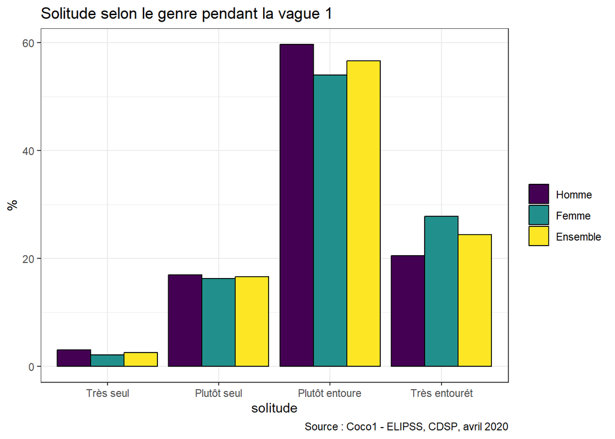

```r
vg1_genre_solitude %>%
  data.frame() %>%
  filter(solitude !="Total") %>%
  ggplot()+
  aes(fill=sexe, x=solitude, y= Freq) %>%
  geom_bar(col="black",stat="identity", position="dodge")+
  labs(title="Solitude selon le genre pendant la vague 1",
       y="%",fill="",
       caption = "Source : Coco1 - ELIPSS, CDSP, avril 2020")+
  viridis::scale_fill_viridis(discrete=T)+
  theme_bw()
```

```r
vg6_genre_solitude <- rprop(table(sexe=coco6$sexe,
            solitude=coco6$solitude))
vg6_genre_solitude
```

```
##           solitude
## sexe       Très seul Plutôt seul Plutôt entoure Très entourét Ne sait pas Total
##   Homme      1.7      16.4        66.6           15.3           0.0       100.0
##   Femme      1.3      19.1        56.6           22.9           0.2       100.0
##   Ensemble   1.5      17.8        61.2           19.4           0.1       100.0
```

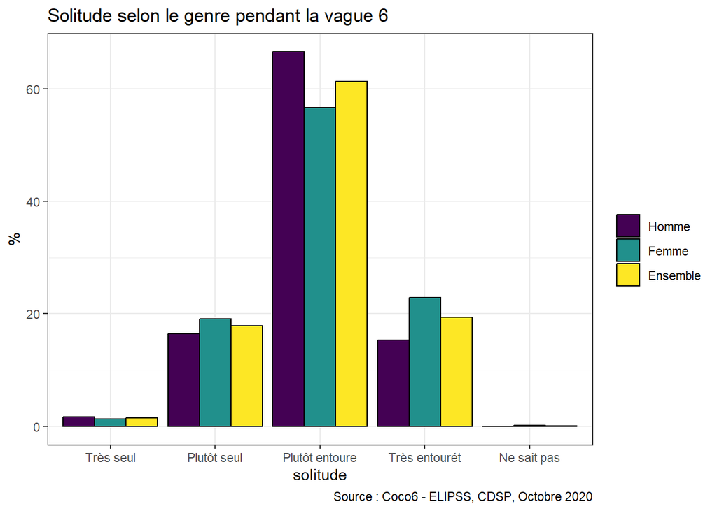

```r
vg6_genre_solitude %>%
  data.frame() %>%
  filter(solitude !="Total") %>%
  ggplot()+
  aes(fill=sexe, x=solitude, y= Freq) %>%
  geom_bar(col="black",stat="identity", position="dodge")+
  labs(title="Solitude selon le genre pendant la vague 6",
       y="%",fill="",
       caption = "Source : Coco6 - ELIPSS, CDSP, Octobre 2020")+
  viridis::scale_fill_viridis(discrete=T)+
  theme_bw()
```

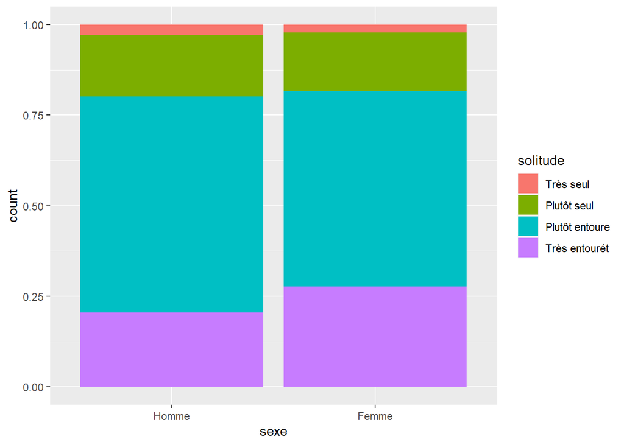

```r
coco1 %>%
  filter(is.na(solitude)==F) %>%
ggplot()+
  aes(fill=solitude, x=sexe)+
  geom_bar(position="fill")
```

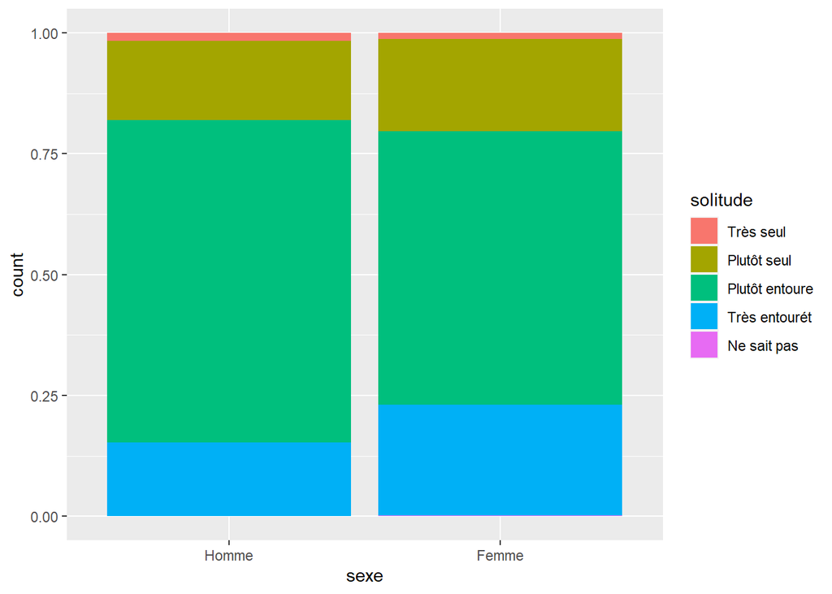

```r
coco6 %>%
  filter(is.na(solitude)==F) %>%
ggplot()+
  aes(fill=solitude, x=sexe)+
  geom_bar(position="fill")
```

```r
#fusionner les deux vagues
s_solitude <- cbind(solitude6, solitude6)
#presenter le tableau

s_solitude_df <- as.data.frame(s_solitude)
colnames(s_solitude_df) <- c("Homme", "Femme", "Total", "homme", "femme", "total")

s_solitude_df <- rownames_to_column(s_solitude_df, "Degré de solitude")

#library(gt)
s_solitude_df %>%
  gt() %>%
  tab_spanner(label = "Vague 1", columns = c(2, 3, 4)) %>%
  tab_spanner(label = "Vague 6", columns = c(5, 6, 7)) %>%
  tab_style(
    style = list(cell_text(weight = "bold")),
    locations = cells_body(columns = c(4,7)))
```

[output not shown]

### 2.2.2 Degré des Nerveux, Decourage et Triste

```r
# Créer la fonction
fct_freq_senti <- function(x){
  recod <- fct_collapse(factor(x),
  "En permanence"="1",
  "Souvent"="2",
  "Quelques fois"="3",
  "Rarement"="4",
  "Jamais" = "5",
  "Ne sait pas" = "9999"
  )
  return(recod)
}

#la fonction pour le sentiment 'nerveux' vague 1 uniquement
fct_freq_senti_nerv <- function(x){
  recod <- fct_collapse(factor(x),
                        "En permanence"="1",
                        "Souvent"="2",
                        "Quelques fois"="3",
                        "Rarement"="4",
                        "Jamais" = "5"
  )
  return(recod)
}
# Recodage
coco1$nerveux <- fct_freq_senti(coco1$coco1_q16)
coco1$decourage <- fct_freq_senti(coco1$coco1_q17)
coco1$triste <- fct_freq_senti(coco1$coco1_q19)

coco6$nerveux <- fct_freq_senti(coco6$coco6_Q16)
coco6$decourage <- fct_freq_senti(coco6$coco6_Q17)
coco6$triste <- fct_freq_senti(coco6$coco6_Q19)
```

**Nerveux**

```r
nerveux1<-wtd.table(coco1$nerveux,coco1$sexe,
          weights = coco1$coco1_POIDS, useNA = "ifany") %>%
  prop(digits=1)

nerveux6<-wtd.table(coco6$nerveux,coco6$sexe,
          weights = coco6$POIDS_coco6, useNA = "ifany") %>%
  prop(digits=1)
```

*Graphique : Nerveux*

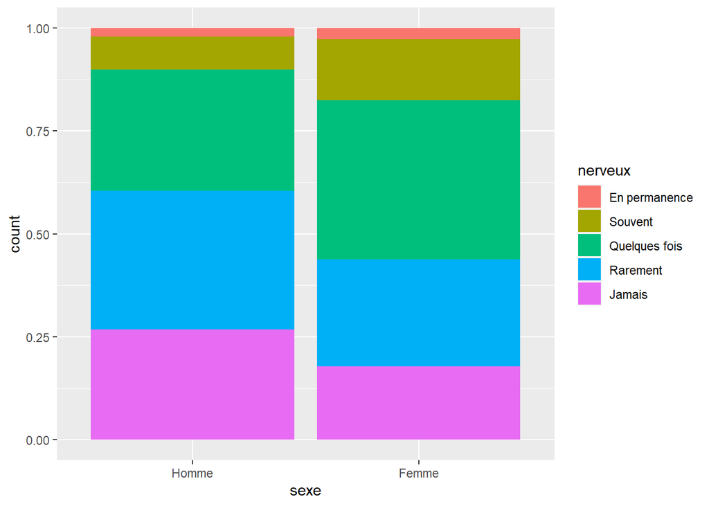

```r
coco1 %>%
  filter(is.na(nerveux)==F) %>%
ggplot()+
  aes(fill=nerveux, x=sexe)+
  geom_bar(position="fill")
```

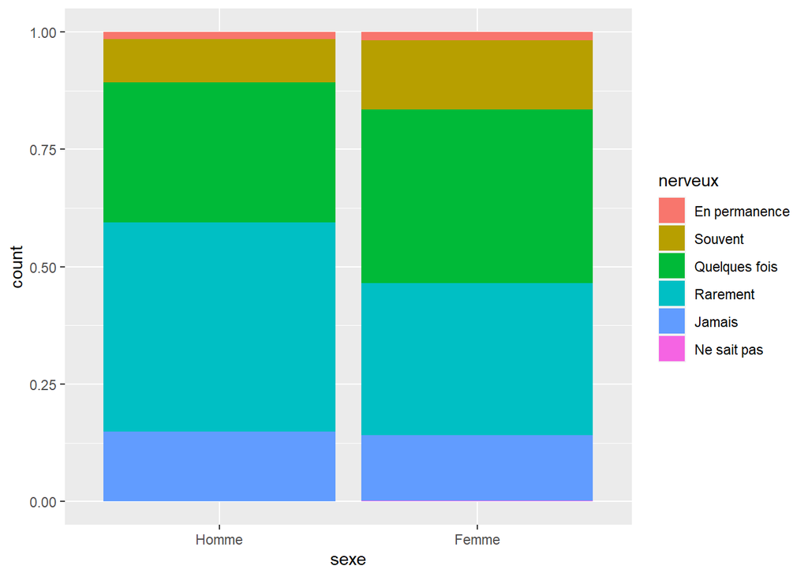

```r
coco6 %>%
  filter(is.na(nerveux)==F) %>%
ggplot()+
  aes(fill=nerveux, x=sexe)+
  geom_bar(position="fill")
```

Ensuite, la nervosité. Si l’on compare les hommes et les femmes, le pourcentage d’hommes et de femmes qui sont toujours nerveux est la presque même lors de la vague1, mais cette tendance est plus forte chez les hommes. Cependant, lors de les vagues 1 et 6, en general, les femmes étaient toujours plus nerveuses que les hommes. Cela suggère que certains facteurs ont rendu les femmes plus négatives dans une période prolongée de confinement.

**Dcourage**

```r
decourage1<-wtd.table(coco1$decourage,coco1$sexe,
          weights = coco1$coco1_POIDS, useNA = "ifany") %>%
  prop(digits=1)

decourage6<-wtd.table(coco6$decourage,coco6$sexe,
          weights = coco6$POIDS_coco6, useNA = "ifany") %>%
  prop(digits=1)
```

*Graphique : Decourage*

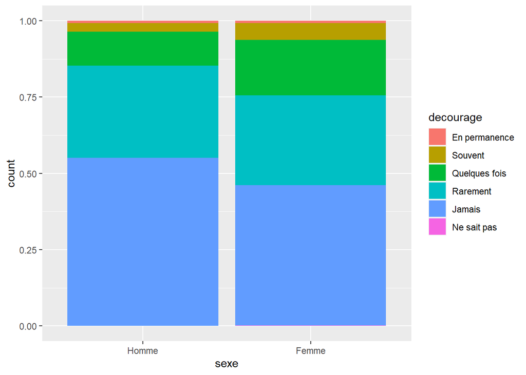

```r
coco1 %>%
  filter(is.na(decourage)==F) %>%
ggplot()+
  aes(fill=decourage, x=sexe)+
  geom_bar(position="fill")
```

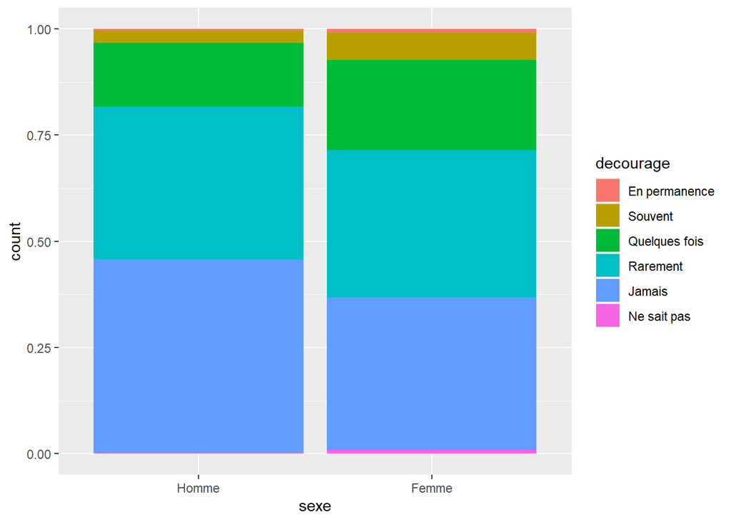

```r
coco6 %>%
  filter(is.na(decourage)==F) %>%
ggplot()+
  aes(fill=decourage, x=sexe)+
  geom_bar(position="fill")
```

```r
#fusionner les deux vagues
s_decourage <- cbind(decourage1, decourage6)
#presenter le tableau

s_decourage_df <- as.data.frame(s_decourage)
colnames(s_decourage_df) <- c("Homme", "Femme", "Total", "homme", "femme", "total")

s_decourage_df <- rownames_to_column(s_decourage_df, "Degré de decourage")

s_decourage_df %>%
  gt() %>%
  tab_spanner(label = "Vague 1", columns = c(2, 3, 4)) %>%
  tab_spanner(label = "Vague 6", columns = c(5, 6, 7)) %>%
  tab_style(
    style = list(cell_text(weight = "bold")),
    locations = cells_body(columns = c(4,7)))
```

| Degré de decourage | Vague 1 Homme | Vague 1 Femme | Vague 1 Total | Vague 6 homme | Vague 6 femme | Vague 6 total |
| --- | --- | --- | --- | --- | --- | --- |
| En permanence | 0.6376057 | 0.28419352 | 0.92179917 | 0.15959649 | 0.3142436 | 0.4738401 |
| Souvent | 1.6121851 | 2.63452570 | 4.24671075 | 2.29694906 | 5.1542436 | 7.4511927 |
| Quelques fois | 7.1357527 | 9.79449338 | 16.93024605 | 8.56615103 | 10.3250580 | 18.8912091 |
| Rarement | 13.5409251 | 15.24766569 | 28.78859084 | 17.58643828 | 18.8787690 | 36.4652073 |
| Jamais | 26.2648121 | 22.77837183 | 49.04318396 | 20.32536752 | 16.0047596 | 36.3301271 |
| Ne sait pas | 0.0000000 | 0.06946923 | 0.06946923 | 0.08549762 | 0.3029261 | 0.3884237 |
| Total | 49.1912807 | 50.80871935 | 100.00000000 | 49.01999999 | 50.9800000 | 100.0000000 |

**Triste**

```r
triste1 <- wtd.table(coco1$triste,coco1$sexe,
          weights = coco1$coco1_POIDS, useNA = "ifany") %>%
  prop(digits=1)

triste6 <- wtd.table(coco6$triste,coco6$sexe,
          weights = coco6$POIDS_coco6, useNA = "ifany") %>%
  prop(digits=1)
```

*Graphique : triste*

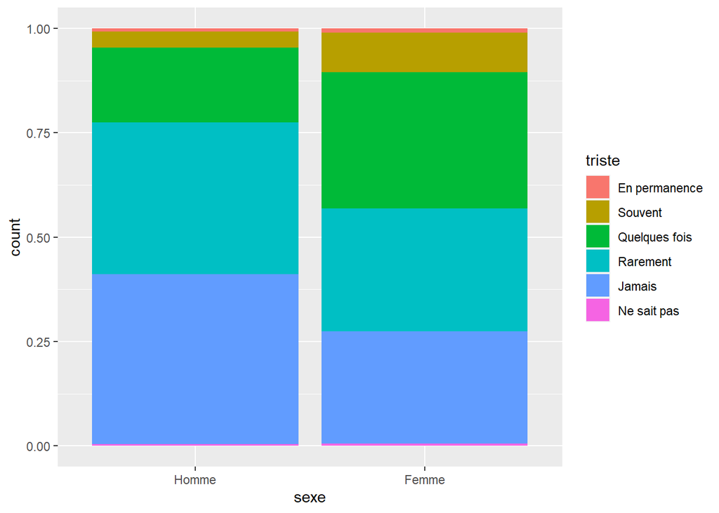

```r
coco1 %>%
  filter(is.na(triste)==F) %>%
ggplot()+
  aes(fill=triste, x=sexe)+
  geom_bar(position="fill")
```

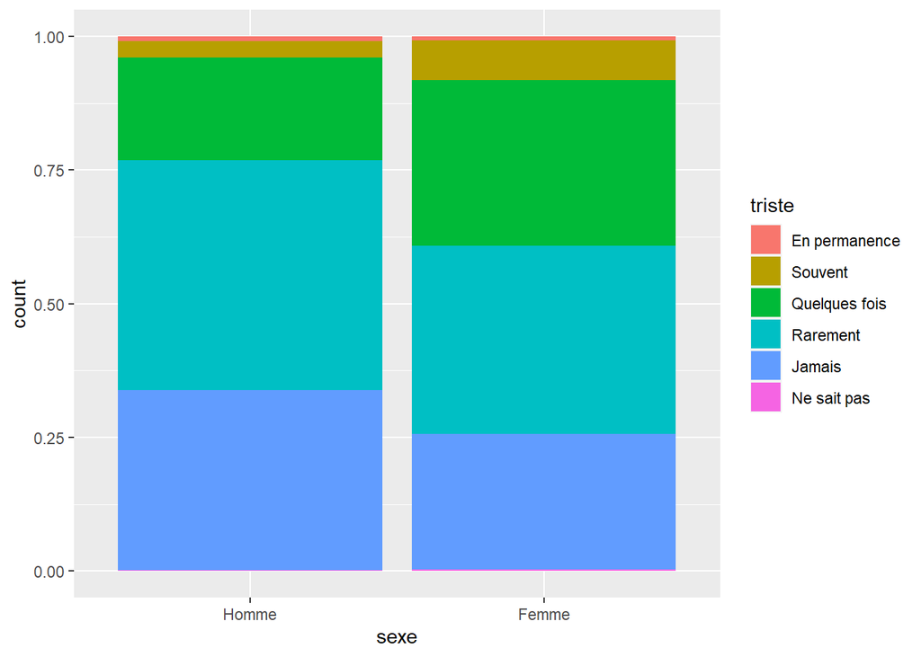

```r
coco6 %>%
  filter(is.na(triste)==F) %>%
ggplot()+
  aes(fill=triste, x=sexe)+
  geom_bar(position="fill")
```

```r
#fusionner les deux vagues
s_triste <- cbind(triste1, triste6)
#presenter le tableau

s_triste_df <- as.data.frame(s_triste)
colnames(s_triste_df) <- c("Homme", "Femme", "Total", "homme", "femme", "total")

s_triste_df <- rownames_to_column(s_triste_df, "Degré de triste")

#library(gt)
s_triste_df %>%
  gt() %>%
  tab_spanner(label = "Vague 1", columns = c(2, 3, 4)) %>%
  tab_spanner(label = "Vague 6", columns = c(5, 6, 7)) %>%
  tab_style(
    style = list(cell_text(weight = "bold")),
    locations = cells_body(columns = c(4,7)))
```

| Degré de triste | Vague 1 Homme | Vague 1 Femme | Vague 1 Total | Vague 6 homme | Vague 6 femme | Vague 6 total |
| --- | --- | --- | --- | --- | --- | --- |
| En permanence | 0.5615592 | 0.4413033 | 1.0028625 | 0.32108047 | 0.3000809 | 0.6211613 |
| Souvent | 2.6154669 | 4.2332910 | 6.8487579 | 1.79708084 | 5.0698908 | 6.8669717 |
| Quelques fois | 11.0345514 | 18.4437326 | 29.4782840 | 10.25965850 | 15.1224065 | 25.3820650 |
| Rarement | 16.6111295 | 14.3573629 | 30.9684924 | 19.98445999 | 20.2420281 | 40.2264881 |
| Jamais | 18.2247574 | 13.1570439 | 31.3818012 | 16.60914536 | 10.1277574 | 26.7369027 |
| Ne sait pas | 0.1438163 | 0.1759856 | 0.3198019 | 0.04857482 | 0.1178364 | 0.1664112 |
| Total | 49.1912807 | 50.8087193 | 100.0000000 | 49.01999999 | 50.9800000 | 100.0000000 |

## 2.3 Les facteurs qui affecte (éventuellement) le bien-être et la santé mentale

Maintenant on va observer les variables qui peuvent avoir un impact direct ou indirect sur le bien-être et la santé mentale de la population etudiée. Le choix de ces varibles répose sur les trois domaines suivants:

- la santé physique
- la vie sociale
- les activités de la vie quotidiennes, le confinement et le télétravail

### 2.3.1 Santé physique

```r
#état de santé percu (Diriez-vous que, dans l'ensemble, votre santé est :)

#recodage de la variable
fct_sante <- function(x){
  recod <- fct_collapse(factor(x),
  "Très bon"="1",
  "Bon"="2",
  "Assez bon"="3",
  "Mauvais"="4",
  "Très mauvais"="5",
  "N'a pas repondu"="9999")
  return(recod)
}
coco1$sante <- fct_sante(coco1$coco1_q04)
coco6$sante <- fct_sante(coco6$coco6_Q04)

# vague 1
sante_vague1 <- wtd.table(coco1$sante,coco1$sexe, weights = coco1$coco1_POIDS,
          useNA = "ifany", exclude = "N'a pas repondu") %>%
  prop(digits=1)
#vague 6
sante_vague6 <- wtd.table(coco6$sante,coco6$sexe, weights = coco6$POIDS_coco6,
          useNA = "ifany", exclude = "N'a pas repondu") %>%
  prop(digits=1)

#fusionner les deux vagues
t_sante <- cbind(sante_vague1, sante_vague6)
#presenter le tableau

t_sante_df <- as.data.frame(t_sante)
colnames(t_sante_df) <- c("Homme", "Femme", "Total", "homme", "femme", "total")


t_sante_df <- rownames_to_column(t_sante_df, "Etat de santé")


t_sante_df %>%
  gt() %>%
  tab_spanner(label = "Vague 1", columns = c(2, 3, 4)) %>%
  tab_spanner(label = "Vague 6", columns = c(5, 6, 7)) %>%
  tab_style(style = list(cell_text(weight = "bold")),
            locations = cells_body(columns = c(4,7)))
```

| Etat de santé | Vague 1 Homme | Vague 1 Femme | Vague 1 Total | Vague 6 homme | Vague 6 femme | Vague 6 total |
| --- | --- | --- | --- | --- | --- | --- |
| Très bon | 10.0853145 | 10.9695978 | 21.0549123 | 9.4279732 | 12.699168 | 22.1271411 |
| Bon | 23.7363871 | 27.5854493 | 51.3218363 | 27.4439882 | 26.732489 | 54.1764767 |
| Assez bon | 12.7887511 | 10.5108440 | 23.2995950 | 9.6957507 | 9.575701 | 19.2714517 |
| Mauvais | 2.1682360 | 1.5096686 | 3.6779046 | 2.2569230 | 1.990783 | 4.2477059 |
| Très mauvais | 0.4297688 | 0.2159829 | 0.6457517 | 0.1772246 | 0.000000 | 0.1772246 |
| Total | 49.2084574 | 50.7915426 | 100.0000000 | 49.0018596 | 50.998140 | 100.0000000 |

Les personnes interrogées se declarent majoritairement (~95%) en très bon, bon ou assez bon état de santé et il n’y a pas de differences significatives entre les deux vagues de l’enquete ainsi que entre les deux sexes.

### 2.3.2 Poids des individus

```r
# coco1_q05_c: Poids en kg
#recodage
fct_poids <- function(x){
  recod <- fct_collapse(factor(x),
  "Moins de 55 kg"="1",
  "Entre 55 et 64 kg"= c("2","3"),
  "Entre 65 et 74"= c("4", "5"),
  "Entre 75 et 84 heures"= c("6","7"),
  "85 kg et plus"= c("8", "9"),
  "RefRep,NSP,NR" = c("7777","8888","9999"))
  return(recod)
}

coco1$poids <- fct_poids(coco1$coco1_q05_c)
coco6$poids <- fct_poids(coco6$coco6_Q05_c)


#vague 1
poids1 <- wtd.table(coco1$poids,coco1$sexe, weights = coco1$coco1_POIDS,
          useNA = "ifany", exclude = "RefRep,NSP,NR") %>%
  prop(digits=1)

#vague 6
poids6 <- wtd.table(coco6$poids,coco6$sexe, weights = coco6$POIDS_coco6,
          useNA = "ifany", exclude = "RefRep,NSP,NR") %>%
  prop(digits=1)

#fusionner les deux vagues
t_poids <- cbind(poids1, poids6)
#presenter le tableau

t_poids_df <- as.data.frame(t_poids)
colnames(t_poids_df) <- c("Homme", "Femme", "Total", "homme", "femme", "total")

t_poids_df <- rownames_to_column(t_poids_df, "Poids")


t_poids_df %>%
  gt() %>%
  tab_spanner(label = "Vague 1", columns = c(2, 3, 4)) %>%
  tab_spanner(label = "Vague 6", columns = c(5, 6, 7)) %>%
  tab_style(
    style = list(cell_text(weight = "bold")),
    locations = cells_body(columns = c(4,7)))
```

| Poids | Vague 1 Homme | Vague 1 Femme | Vague 1 Total | Vague 6 homme | Vague 6 femme | Vague 6 total |
| --- | --- | --- | --- | --- | --- | --- |
| Moins de 55 kg | 0.6413614 | 8.978893 | 9.620255 | 0.5659658 | 8.021872 | 8.587838 |
| Entre 55 et 64 kg | 3.1392163 | 14.989595 | 18.128811 | 2.4279310 | 13.341315 | 15.769246 |
| Entre 65 et 74 | 10.0281721 | 14.795872 | 24.824044 | 13.9278056 | 15.870843 | 29.798649 |
| Entre 75 et 84 heures | 27.8327590 | 7.797525 | 35.630284 | 12.4431341 | 4.617938 | 17.061072 |
| 85 kg et plus | 9.2218569 | 2.574749 | 11.796606 | 22.4520989 | 6.331097 | 28.783195 |
| Total | 50.8633657 | 49.136634 | 100.000000 | 51.8169354 | 48.183065 | 100.000000 |

En revanche, le poids des enquêtées semble d’être affecté par le confinement, puisque lors de la deuxième vague de l’enquête la proportion des personnes obèses (85kg et plus) est d’environ 2 fois et demi supérieur à celle de la première vague(il est passé de 11,8% à 28,8% après le confinement). Ces resultats sont cohérents avec ceux obtenus dans une étude mené par la Santé Publique dans le but d’observer les comportements alimentaires des Français pendant le confinement (“Comportements alimentaires et déterminants de la prise de poids des adultes en France pendant le confinement lié à la Covid-19: évolutions perçues” (CoviPrev, 2020)).

### 2.3.3 Fréquence de l’activité sportive

```r
#eayy_K3: Fréquence activité sportive 30 minutes d'affilée

#recodage de la variable
fct_sport <- function(x){
  recod <- fct_collapse(factor(x),
  "Tous les jours"="1",
  "Plusieurs fois par semaine"="2",
  "Une fois par semaine"="3",
  "1 à 3 fois par mois"="4",
  "Moins souvent"="5",
  "9"="9")
  return(recod)
}

coco1$sport <- fct_sport(coco1$eayy_K3)
coco6$sport <- fct_sport(coco6$eayy_K3)

sport1 <- wtd.table(coco1$sport, coco1$sexe, weights = coco1$coco1_POIDS,
          exclude = "9",useNA = "ifany") %>%
  prop(digits=1)

sport6 <- wtd.table(coco6$sport, coco6$sexe, weights = coco6$POIDS_coco6,
          exclude = "9", useNA = "ifany") %>%
  prop(digits=1)

#fusionner les deux vagues
t_sport <- cbind(sport1, sport6)
#presenter le tableau

t_sport_df <- as.data.frame(t_sport)
colnames(t_sport_df) <- c("Homme", "Femme", "Total", "homme", "femme", "total")

t_sport_df <- rownames_to_column(t_sport_df, "Fréquence")

t_sport_df %>%
  gt() %>%
  tab_spanner(label = "Vague 1", columns = c(2, 3, 4)) %>%
  tab_spanner(label = "Vague 6", columns = c(5, 6, 7)) %>%
  tab_style(
    style = list(cell_text(weight = "bold")),
    locations = cells_body(columns = c(4,7)))
```

| Fréquence | Vague 1 Homme | Vague 1 Femme | Vague 1 Total | Vague 6 homme | Vague 6 femme | Vague 6 total |
| --- | --- | --- | --- | --- | --- | --- |
| Tous les jours | 13.387553 | 7.811938 | 21.199492 | 12.841607 | 8.247347 | 21.088954 |
| Plusieurs fois par semaine | 14.632549 | 16.499886 | 31.132435 | 14.637941 | 17.001939 | 31.639880 |
| Une fois par semaine | 7.999411 | 9.319755 | 17.319166 | 8.490457 | 8.394937 | 16.885395 |
| 1 à 3 fois par mois | 4.894085 | 4.161670 | 9.055755 | 4.521098 | 4.457854 | 8.978952 |
| Moins souvent | 8.340868 | 12.952284 | 21.293152 | 8.607266 | 12.799553 | 21.406819 |
| Total | 49.254468 | 50.745532 | 100.000000 | 49.098369 | 50.901631 | 100.000000 |

Les femmes sont légerement plus susceptibles de pratiquer une activité sportive 30 minutes d’affilée plusieurs fois par semaine au lieu de tous les jours. Sinon, avec la fréquence moins elevé les résultats obtenus pendant le confinement ainsi que après sa fin sont similaires entre les deux sexes.

### 2.3.4 Le sommeil

```r
# coco1_q59_6: Temps consacré à dormir
fct_temps_actvt <- function(x){
  recod <- fct_collapse(factor(x),
  "Je n’ai pas fait cette activité"="1",
  "Entre 0 et 4 heure"= c("2","3","4", "5"),
  "Entre 4 et 6 heures"="6",
  "Entre 6 et 8 heures"="7",
  "8 heures et plus"= c("8", "9"),
  "9999" = "9999")
  return(recod)
}


coco1$sommeil <- fct_temps_actvt(coco1$coco1_q59_6)
coco6$sommeil <- fct_temps_actvt(coco6$coco6_q59_6)

#vague 1
sommeil_1 <- wtd.table(coco1$sommeil, coco1$sexe, weights = coco1$coco1_POIDS, exclude = "9999",useNA = "ifany") %>%
  prop(digits=1)

#vague 6
sommeil_6 <- wtd.table(coco6$sommeil, coco6$sexe, weights = coco6$POIDS_coco6, exclude = "9999",useNA = "ifany") %>%
  prop(digits=1)

#fusionner les deux vagues
t_sommeil <- cbind(sommeil_1, sommeil_6)

#présenter le tableau

t_sommeil_df <- as.data.frame(t_sommeil)
colnames(t_sommeil_df) <- c("Homme", "Femme", "Total", "homme", "femme", "total")

t_sommeil_df <- rownames_to_column(t_sommeil_df, "Fréquence")

t_sommeil_df %>%
  gt() %>%
  tab_spanner(label = "Vague 1", columns = c(2, 3, 4)) %>%
  tab_spanner(label = "Vague 6", columns = c(5, 6, 7)) %>%
  tab_style(
    style = list(cell_text(weight = "bold")),
    locations = cells_body(columns = c(4,7)))
```

| Fréquence | Vague 1 Homme | Vague 1 Femme | Vague 1 Total | Vague 6 homme | Vague 6 femme | Vague 6 total |
| --- | --- | --- | --- | --- | --- | --- |
| Je n’ai pas fait cette activité | 6.011154 | 4.961444 | 10.97260 | 2.128401 | 2.852893 | 4.981294 |
| Entre 0 et 4 heure | 6.491223 | 5.014273 | 11.50550 | 5.338903 | 4.621082 | 9.959985 |
| Entre 4 et 6 heures | 5.760683 | 5.548634 | 11.30932 | 6.358536 | 7.856321 | 14.214857 |
| Entre 6 et 8 heures | 16.583559 | 19.778333 | 36.36189 | 26.374812 | 24.190898 | 50.565710 |
| 8 heures et plus | 14.691309 | 15.159386 | 29.85070 | 9.258423 | 11.019732 | 20.278155 |
| Total | 49.537929 | 50.462071 | 100.00000 | 49.459074 | 50.540926 | 100.000000 |

On trouve quelques changement dans les habitudes de sommeil des Français après le premier confinement. Par exemple, lors de la deuxième vague de l’enquete la moitié des personnes interrogées a déclaré d’avoir consacré entre 6h et 8h par jour pour le sommeil pendant les deux dernières semaines contre 36% au debut du confinement. Pourtant, le nombre des personnes qui dort 8h et a baissé de 10% après le confinement.

## 2.4 La vie sociale

On vit dans la sosiété c’est-à-dire que l’on cammunique avec les gens comme d’habitude mais il y a une difficulté pendant le confinement. Est-ce que l’on a la chance de communiquer avec des amis et la famille dans la vie réelle?

### 2.4.1 Rencontres avec des amis

```r
### coco1_q52_1: Fréquence des rencontres avec des amis dans la vie réelle
#Pendant les deux dernières semaines, à quelle fréquence avez-vous vu les personnes suivantes (en dehors des personnes avec qui vous logez) ?
# Créer la fonction
fct_freq_renco <- function(x){
  recod <- fct_collapse(factor(x),
  "8 fois ou plus"="1",
  "Entre 5 et 7 fois"="2",
  "3 ou 4 fois"="3",
  "1 ou 2 fois"="4",
  "Jamais" = "5")
  return(recod)
}
# Recodage
coco1$rencontres_amis_reel <- fct_freq_renco(coco1$coco1_q52_1)
coco6$rencontres_amis_reel <- fct_freq_renco(coco6$coco6_q52_1)

#vague 1
renco_amis1 <- wtd.table(coco1$rencontres_amis_reel, coco1$sexe, weights = coco1$coco1_POIDS, exclude = "9999",useNA = "ifany") %>%
  prop(digits=1)

#vague 6
renco_amis6 <- wtd.table(coco6$rencontres_amis_reel, coco6$sexe, weights = coco6$POIDS_coco6, exclude = "9999",useNA = "ifany") %>%
  prop(digits=1)

#fusionner les deux vagues
t_renco_amis <- cbind(renco_amis1, renco_amis6)

#présenter le tableau

t_renco_amis_df <- as.data.frame(t_renco_amis)
colnames(t_renco_amis_df) <- c("Homme", "Femme", "Total", "homme", "femme", "total")

t_renco_amis_df <- rownames_to_column(t_renco_amis_df, "Fréquence")

t_renco_amis_df %>%
  gt() %>%
  tab_spanner(label = "Vague 1", columns = c(2, 3, 4)) %>%
  tab_spanner(label = "Vague 6", columns = c(5, 6, 7)) %>%
  tab_style(
    style = list(cell_text(weight = "bold")),
    locations = cells_body(columns = c(4,7)))
```

| Fréquence | Vague 1 Homme | Vague 1 Femme | Vague 1 Total | Vague 6 homme | Vague 6 femme | Vague 6 total |
| --- | --- | --- | --- | --- | --- | --- |
| 8 fois ou plus | 0.4656579 | 0.280390975 | 0.7460489 | 3.685185 | 0.6802516 | 4.365437 |
| Entre 5 et 7 fois | 0.3112471 | 0.008876743 | 0.3201239 | 2.770793 | 2.8405985 | 5.611391 |
| 3 ou 4 fois | 0.5557640 | 1.234878844 | 1.7906428 | 9.862626 | 8.2818468 | 18.144473 |
| 1 ou 2 fois | 3.9085905 | 3.257038328 | 7.1656288 | 22.324516 | 26.9670603 | 49.291576 |
| Jamais | 44.1310907 | 45.846464929 | 89.9775556 | 10.561280 | 12.0258433 | 22.587123 |
| Total | 49.3723502 | 50.627649820 | 100.0000000 | 49.204399 | 50.7956005 | 100.000000 |

### 2.4.2 Rencontres avec la famille

```r
###coco1_q52_3: Fréquence des rencontres avec la famille dans la vie réelle
# Recodage
coco1$rencontres_fam_reel <- fct_freq_renco(coco1$coco1_q52_3)
coco6$rencontres_fam_reel <- fct_freq_renco(coco6$coco6_q52_3)

#vague 1
renco_fam1 <- wtd.table(coco1$rencontres_fam_reel, coco1$sexe, weights = coco1$coco1_POIDS, exclude = "9999",useNA = "ifany") %>%
  prop(digits=1)

#vague 6
renco_fam6 <- wtd.table(coco6$rencontres_fam_reel, coco6$sexe, weights = coco6$POIDS_coco6, exclude = "9999",useNA = "ifany") %>%
  prop(digits=1)

#fusionner les deux vagues
t_renco_fam <- cbind(renco_fam1, renco_fam6)

#présenter le tableau

t_renco_fam_df <- as.data.frame(t_renco_fam)
colnames(t_renco_fam_df) <- c("Homme", "Femme", "Total", "homme", "femme", "total")

t_renco_fam_df <- rownames_to_column(t_renco_fam_df, "Fréquence")

t_renco_fam_df %>%
  gt() %>%
  tab_spanner(label = "Vague 1", columns = c(2, 3, 4)) %>%
  tab_spanner(label = "Vague 6", columns = c(5, 6, 7)) %>%
  tab_style(
    style = list(cell_text(weight = "bold")),
    locations = cells_body(columns = c(4,7)))
```

| Fréquence | Vague 1 Homme | Vague 1 Femme | Vague 1 Total | Vague 6 homme | Vague 6 femme | Vague 6 total |
| --- | --- | --- | --- | --- | --- | --- |
| 8 fois ou plus | 0.4332772 | 0.6035109 | 1.036788 | 5.255646 | 3.760455 | 9.016101 |
| Entre 5 et 7 fois | 0.4575058 | 0.7284311 | 1.185937 | 5.461020 | 1.894670 | 7.355691 |
| 3 ou 4 fois | 1.3909072 | 0.8607323 | 2.251640 | 10.303163 | 12.180518 | 22.483681 |
| 1 ou 2 fois | 7.0542967 | 6.0961786 | 13.150475 | 19.051428 | 24.458343 | 43.509770 |
| Jamais | 40.0276560 | 42.3475042 | 82.375160 | 9.220608 | 8.414149 | 17.634757 |
| Total | 49.3636429 | 50.6363571 | 100.000000 | 49.291865 | 50.708135 | 100.000000 |

## 2.5 Les activités de la vie quotidienne et les avis sur le confinement et le télétravail

### 2.5.1 Temps consacré à faire du ménage (pendant le confinement)

```r
fct_temps_menage <- function(x){
  recod <- fct_collapse(factor(x),
  "Je n’ai pas fait cette activité"="1",
  "Entre 0 et 1 heure"= "2",
  "Entre 1 et 2 heaures" = "3",
  "Entre 2 et 3 heures" = "4",
  "Entre 3 et 10 heures"= c("5","6", "7", "8"),
  "10 heures et plus"="7",
  "PDR" = "9999")
  return(recod)
}


coco1$menage <- fct_temps_menage(coco1$coco1_q59_1)

wtd.table(coco1$menage, coco1$sexe, weights = coco1$coco1_POIDS, exclude = c("9999", "9", "PDR"),useNA = "ifany") %>%
  prop(digits=1)
```

```
##                                 Homme Femme Total
## Je n’ai pas fait cette activité   7.9   1.9   9.7
## Entre 0 et 1 heure               23.4  20.7  44.1
## Entre 1 et 2 heaures             12.8  16.1  28.9
## Entre 2 et 3 heures               5.0   5.1  10.0
## Entre 3 et 10 heures              1.4   3.9   5.3
## 10 heures et plus                 0.0   1.9   1.9
## Total                            50.4  49.6 100.0
```

La majorité des personnes (83%) au début du confinement consacrent en moyenne entre 0 et 3h par jour pour le ménage. Globalement, les femmes sont plus nombreuses à s’occuper du menage selon les resultas obténus. Environ 7,2% des interrogés consacrent entre plus de 3h par jour pour cette tâche dont 5,8% sont les femmes.

### 2.5.2 Confinement

*Description de l’expérience du confinement*

```r
#coco1_q62:

fct_conf <- function(x){
  recod <- fct_collapse(factor(x),
  "C'est une expérience qui nous fait perdre beaucoup de temps" = "1",
  "C'est une expérience qui permet de prendre du recul et réfléchir à
son mode de vie"= "2",
  "C'est une expérience qui permet de consacrer du temps à des choses
essentielles comme la famille, les amis et les enfants"="3",
  "C’est une expérience qui fatigue les nerfs"="4",
  "PDR" = "9999")
  return(recod)
}

coco1$conf <- fct_conf(coco1$coco1_q62)
coco6$conf <- fct_conf(coco6$coco6_Q62mod)

#vague 1
conf_1 <- wtd.table(coco1$conf, coco1$sexe, weights = coco1$coco1_POIDS, exclude = c("PDR","9999"),,useNA = "ifany") %>%
  prop(digits=1)

#vague 6
conf_6 <- wtd.table(coco6$conf, coco6$sexe, weights = coco6$POIDS_coco6, exclude = c("PDR","9999"),useNA = "ifany") %>%
  prop(digits=1)

#fusionner les deux vagues
t_conf_df <- cbind(conf_1, conf_6)

#présenter le tableau

t_conf_df <- as.data.frame(t_conf_df)
colnames(t_conf_df) <- c("Homme", "Femme", "Total", "homme", "femme", "total")

t_conf_df <- rownames_to_column(t_conf_df, "Avis sur l'expérience du confinement")

t_conf_df %>%
  gt() %>%
  tab_spanner(label = "Vague 1", columns = c(2, 3, 4)) %>%
  tab_spanner(label = "Vague 6", columns = c(5, 6, 7)) %>%
  tab_style(
    style = list(cell_text(weight = "bold")),
    locations = cells_body(columns = c(4,7)))
```

| Avis sur l'expérience du confinement | Vague 1 Homme | Vague 1 Femme | Vague 1 Total | Vague 6 homme | Vague 6 femme | Vague 6 total |
| --- | --- | --- | --- | --- | --- | --- |
| C'est une expérience qui nous fait perdre beaucoup de temps | 4.879389 | 1.894694 | 6.774083 | 8.686130 | 4.586126 | 13.27226 |
| C'est une expérience qui permet de prendre du recul et réfléchir à son mode de vie | 23.669100 | 26.227313 | 49.896412 | 20.443510 | 21.968286 | 42.41180 |
| C'est une expérience qui permet de consacrer du temps à des choses essentielles comme la famille, les amis et les enfants | 13.260763 | 11.428732 | 24.689495 | 8.399345 | 13.360654 | 21.76000 |
| C’est une expérience qui fatigue les nerfs | 8.458062 | 10.181947 | 18.640010 | 11.834394 | 10.721555 | 22.55595 |
| Total | 50.267315 | 49.732685 | 100.000000 | 49.363379 | 50.636621 | 100.00000 |

Au moment de la prémière vague de l’enquete un quart (26%) de la population s’exprime négativement concernant le confinement. En effet, environ 7% le voient comme la perte de temps et pour 19% c’est une experience qui fatigue les nerfs. Quelques mois après le confinement, le nombre des personnes avec ces opinions atteint 36%.

### 2.5.3 Stress lié au confinement

```r
#Dans l’ensemble le confinement vous pèse…

fct_stress_conf <- function(x){
  recod <- fct_collapse(factor(x),
  "0 Pas du tout" = "0",
  "10 Enormément"="10")
  return(recod)
}

coco1$conf_stress <- fct_stress_conf(coco1$coco1_q64)

#vague 1
wtd.table(coco1$conf_stress, coco1$sexe, weights = coco1$coco1_POIDS, exclude = "9999",,useNA = "ifany") %>%
  prop(digits=1)
```

```
##               Homme Femme Total
## 0 Pas du tout   4.0   3.2   7.2
## 1               2.2   2.4   4.6
## 2               4.2   3.9   8.1
## 3               5.1   5.0  10.1
## 4               2.3   3.7   6.0
## 5               8.0   6.7  14.7
## 6               5.6   6.7  12.3
## 7               8.7   8.6  17.3
## 8               5.9   6.9  12.8
## 9               1.4   1.3   2.7
## 10 Enormément   2.1   2.2   4.3
## Total          49.4  50.6 100.0
```

Pour la moitié de la population le confinement est une expérience assez ou énormèment stressante(sur l’échelle de 0 à 10 ils ont choisi 6,7,8,9 ou 10). Seulement 7% des personnes considèrent que le confinèment n’est pas du tout stressant pour elles(0). Selon les résultats obténus, les femmes et les hommes sont affecté par le confinement presque de la même manière.

### 2.5.4 *Avis télétravail(après le confinement)*

*Avis télétravail : permet d’optimiser sa journée*

```r
# coco6_Q132_1:

fct_avis_teletravail <- function(x){
  recod <- fct_collapse(factor(x),
  "Oui"="1",
  "Non"= "2",
  "PDR" = "9999")
  return(recod)
}

coco6$avis1 <- fct_avis_teletravail(coco6$coco6_Q132_1)

wtd.table(coco6$avis1, coco6$sexe, weights = coco6$POIDS_coco6, exclude = "PDR",useNA = "ifany") %>%
  prop(digits=1)
```

```
##       Homme Femme Total
## Oui    30.7  31.7  62.4
## Non    18.9  18.7  37.6
## Total  49.6  50.4 100.0
```

*Avis télétravail : permet de se concentrer*

```r
coco6$avis2 <- fct_avis_teletravail(coco6$coco6_Q132_2)

wtd.table(coco6$avis2, coco6$sexe, weights = coco6$POIDS_coco6, exclude = "PDR",useNA = "ifany") %>%
  prop(digits=1)
```

```
##       Homme Femme Total
## Oui    15.1  10.0  25.1
## Non    34.5  40.4  74.9
## Total  49.6  50.4 100.0
```

*Avis télétravail : mélange trop vie privée et vie professionnelle*

```r
coco6$avis3 <- fct_avis_teletravail(coco6$coco6_Q132_3)

wtd.table(coco6$avis3, coco6$sexe, weights = coco6$POIDS_coco6, exclude = "PDR",useNA = "ifany") %>%
  prop(digits=1)
```

```
##       Homme Femme Total
## Oui    18.7  16.4  35.1
## Non    30.9  34.0  64.9
## Total  49.6  50.4 100.0
```

*Avis télétravail : diminue efficacité*

```r
coco6$avis4 <- fct_avis_teletravail(coco6$coco6_Q132_4)

wtd.table(coco6$avis4, coco6$sexe, weights = coco6$POIDS_coco6, exclude = "PDR",useNA = "ifany") %>%
  prop(digits=1)
```

```
##       Homme Femme Total
## Oui     8.3   6.8  15.2
## Non    41.3  43.6  84.8
## Total  49.6  50.4 100.0
```

Concernant l’avis sur le télétravail, la majorité des répondant pense que ce mode de travail permets d’optimiser sa journée (62%). Par contre, pour le reste de la population ce n’est pas le cas. Par ailleurs, 75% repondent négativement quand on leur demande si le télétravail permets de se concentrer et 35% pensent que le télétravail rend la conciliation de la vie privée avec la vie professionnelle plus compliquée puisque les limites entre les deux disparaissent. Pour 15% de la population le télétravail est également le source une source de la baisse de l’efficacité.

### 2.5.5 Avis sur quotidien (après le confinement)

*Avis sur quotidien : journées denses*

```r
fct_avis_quotidien <- function(x){
  recod <- fct_collapse(factor(x),
  "Tout à fait d'accord" = "1",
  "Plutôt d'accord" = "2",
  "Plutôt pas d'accord" = "3",
  "Pas du tout d'accord" = "4",
  "PDR" = "9999")
  return(recod)
}

coco6$avis_q1 <- fct_avis_quotidien(coco6$coco6_Q200_2)

wtd.table(coco6$avis_q1, coco6$sexe, weights = coco6$POIDS_coco6, exclude = "PDR",useNA = "ifany") %>%
  prop(digits=1)
```

```
##                      Homme Femme Total
## Tout à fait d'accord   5.7   8.2  14.0
## Plutôt d'accord       21.4  18.3  39.7
## Plutôt pas d'accord   18.7  18.1  36.8
## Pas du tout d'accord   3.6   6.0   9.5
## Total                 49.3  50.7 100.0
```

*Avis sur quotidien : permet de profiter de la vie*

```r
coco6$avis_q2 <- fct_avis_quotidien(coco6$coco6_Q200_3)

wtd.table(coco6$avis_q2, coco6$sexe, weights = coco6$POIDS_coco6, exclude = "PDR",useNA = "ifany") %>%
  prop(digits=1)
```

```
##                      Homme Femme Total
## Tout à fait d'accord   5.3   3.0   8.2
## Plutôt d'accord       21.4  20.3  41.7
## Plutôt pas d'accord   17.2  21.1  38.3
## Pas du tout d'accord   5.3   6.4  11.7
## Total                 49.2  50.8 100.0
```

*Avis sur quotidien : stress intense*

```r
coco6$avis_q3 <- fct_avis_quotidien(coco6$coco6_Q200_4)

wtd.table(coco6$avis_q3, coco6$sexe, weights = coco6$POIDS_coco6, exclude = "PDR",useNA = "ifany") %>%
  prop(digits=1)
```

```
##                      Homme Femme Total
## Tout à fait d'accord   1.8   2.0   3.8
## Plutôt d'accord       11.5  12.1  23.5
## Plutôt pas d'accord   22.4  24.7  47.1
## Pas du tout d'accord  13.6  12.0  25.6
## Total                 49.2  50.8 100.0
```

Pour 53% de la population étudiée leurs journées sont très denses et frénétiques et la moitie des individus enquêtés ne pense pas que leur vie leurs donne beaucoup d’occasions de profiter de la vie. Enfin, pour le tiers de la population (~28%) leur vie quotidinne est un stress intense.

## 2.6 Test statistique

Maintenant on souhate savoir si le degré de nervosité pendant le confinement est lié avec le fait d’être une femme ou un homme.

### 2.6.1 Tableau croisé

```r
addmargins(table(coco1$sexe, coco1$nerveux, useNA="ifany"))
```

```
##
##         En permanence Souvent Quelques fois Rarement Jamais  Sum
##   Homme            10      41           148      169    135  503
##   Femme            15      85           222      149    102  573
##   Sum              25     126           370      318    237 1076
```

On remarque que le nombre des femmes qui se sentent en premanence, souvent ou quelques fois nerveux pendant les deux semaines précedant l’enquête est significativement plus elévé. Ainsi, cela serait judicieux de tester cette hypothèse avec le test khi-2.

### 2.6.2 Test d’indépendance khi-2

```r
chisq.test(table(coco1$sexe, coco1$coco1_q16))
```

```
##
##  Pearson's Chi-squared test
##
## data:  table(coco1$sexe, coco1$coco1_q16)
## X-squared = 32.602, df = 4, p-value = 1.441e-06
```

D’après les resultas obténus (notamment le p-value), on trouve l’association très significative entre ces deux variables. On peut alors conclure que probablement il existe un lien entre le fait d’être une femme ou un homme et le sentiment de nervosité dû à la pandémie et le confinement.

## 2.7 Carte

**Fond de carte**

```r
# Import du fichier shp :
reg_sf <- st_read(dsn="~/GitHub/R_project/regions/regions-20180101.shp")
class(reg_sf)
```

```
## [1] "sf"         "data.frame"
```

```r
names(reg_sf)
```

```
## [1] "code_insee" "nom"        "nuts2"      "wikipedia"  "surf_km2"
## [6] "geometry"
```

```r
str(reg_sf)
```

[output not shown]

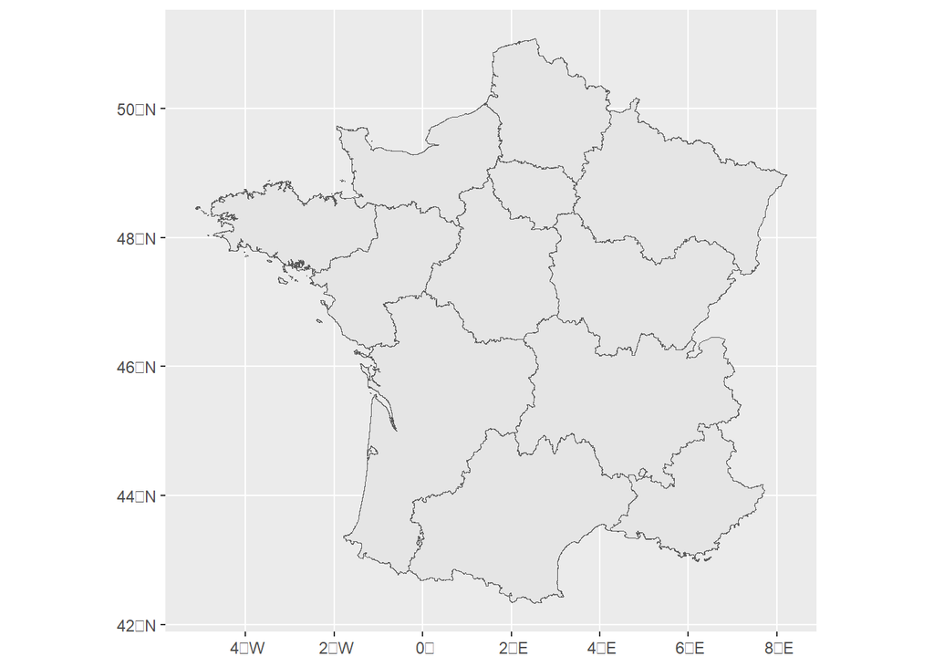

```r
# Supprimer les régions dom-tom d'abord
reg_sf$code_insee
reg_sf2 <- reg_sf %>% slice(-c(1, 2, 3, 8, 12, 14))
ggplot()+
  geom_sf(data=reg_sf2)
```

```r
# Transformer
reg_sf2 <- st_transform(reg_sf2,crs=2154)
```

**Ajout de données**

Depuis le 23 mars 2020, Santé publique France a lancé l’enquête CoviPrev en population générale afin de suivre l’évolution des comportements (gestes barrières, confinement, consommation d’alcool et de tabac, alimentation et activité physique) et de la santé mentale (bien-être, troubles) de la population en France métropolitaine. On va voir la carte du taux de la population ayant l’anxiété durant la vague 1

```r
anx <- read.csv2("~/GitHub/R_project/donnees_anxiete_reg_vague1.csv") # import
names(anx)
```

```
## [1] "reg"     "anxiete"
```

```r
str(anx)
```

```
## 'data.frame':    12 obs. of  2 variables:
##  $ reg    : int  11 24 27 28 32 44 52 53 75 76 ...
##  $ anxiete: num  30.1 24.3 33 24.7 29.6 29.5 26.3 25 22.9 22.6 ...
```

```r
anx$reg = as.character(anx$reg)
#Fusionner
reg_sff <- left_join(reg_sf2, anx, by =c("code_insee" = "reg"))
```

**Carte de l’anxiété selon region**

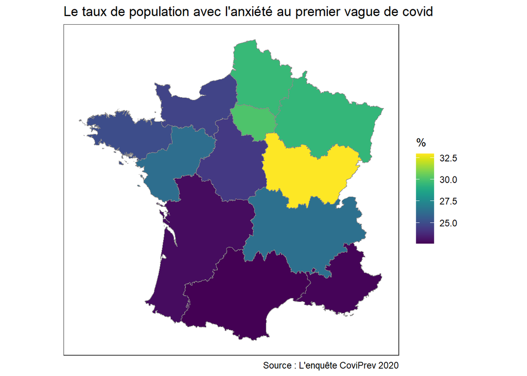

```r
ggplot()+
  geom_sf(data=reg_sff,aes(fill=anxiete),color="snow4",size=.2)+
  viridis::scale_fill_viridis()+
  theme_bw()+
  labs(title = "Le taux de population avec l'anxiété au premier vague de covid",
       fill="%", caption="Source : L'enquête CoviPrev 2020")+
  coord_sf( datum = NA)
```

**Commentaire**

Au cours du première vague en fin mars 2020, les regions où la population a le plus haut taux d’anxiété est Bourgogne-Franche-Comté, puis ce sont Île-de-France, Grand-Est, Hauts-de-France. On peut expliquer cela par la réalité que ce sont aussi les regions où le taux de positivité des tests pour le SARS-CoV-2 au 24 mars 2020 sont le plus haut. Ayant les proches testés positive peut ramener les sentimens négative tel que l’anxiété.

# 3 Conclusion

Les émotions négatives ressenties lors du confinement étaient plus fortement ressenties par les femmes. On suppose donc qu’il y a un certain éléments évoquant ce phénomène.

Nous avons donc examiné la santé physique, la vie sociale et l’avis sur le confinement des hommes et des femmes durant les deux vague du covid : le vague 1 et le vague 6.

Concernant la santé physique, l’obésité était plus répandue chez les hommes alors que les femmes étaient plus susceptibles d’avoi un poids correct. Les hommes sont plus nombreux à pratiquer le sport tous les jours que les femmes mais les femmes semblent plus nombreuses à dormir plus de 8h par jour. On peut imaginer que les hommes ont plus de temps libres à faire certaines activités recréatives comme le sport. En revanche, les femmes ont plutôt besoin de se reposer après avoir fait les tâches toute la journée.

En regardant à l’organisation des tâches ménagères, on voit que les femmes sont plus nombreuses à consacrer plus de deux heures par jour à faire du menage alors que qu’environ 60 % des hommes consacrent moins d’une heure à s’occuper du ménage. Cela suggère que le temps consacré aux tâches ménagères peut être un facteur contribuant aux sentiments négatifs chez les femmes.

Les femmes et les hommes sont affecté par le confinement presque de la même manière car leur niveau de stresse se rassemble. Pourtant, on remarque quelques différences dans le vécu du confinement et du télétravail. Les femmes sont moins nombreuses que les hommes à penser que leur vie quotidienne en confinement leur permet à profiter de la vie et le télétravail leur permet de se concentrer.

Nous pouvons conclure que les femmes et les hommes ont les manières différentes d’organiser leur activités durant le temps des vagues du covid. Le fait de devoir concilier les tâches ménagères, le travail et la vie sociale est probablement la raison pourlaquelle les femmes sont plus nombreuses à se sentir nerveuse que les hommes.